# STRUCTURE DU PRIX DES DENREES ALIMENTAIRES EN COTE D’IVOIRE

# Contexte

Dans le contexte économique actuel, marqué par une inflation constante et une incertitude croissante, la question de la variabilité des prix des produits et leur l’accessibilité dans les différents marchés est devenue cruciale. Les ménages sont contraints de jongler entre le désir de maintenir un certain niveau de vie et la nécessité de s’adapter à une réalité économique de plus en plus difficile. En Côte d’Ivoire, l’Etat s’engage résolument dans la lutte contre la vie chère, à travers certains organismes tels que le CNLVC (Conseil National de Lutte Contre la Vie Chère) et le OCPV (Office d’aide à la Commercialisation des Produits Vivriers). Ses actions visent à atténuer l’impact de l’inflation sur les populations vulnérables et à garantir l’accessibilité des produits de base à tous. Somme toute, ces initiatives sont précieuses pour assurer la stabilité économique et sociale en Côte d’Ivoire.

## Collecte des données et Data processing

### Gestion des valeurs manquantes

Deux cas de figures s’assimilent à l’observation de valeurs manquantes dans notre dataset:  
1. Une indisponibilité du produit dans la région concernée  
2. Un défaut de mesure des prix sur la période concernée

Par suite nous considérons le cas 2.

Pour chaque valeur manquante pour un produit donné dans une ville, une imputation est faite à travers la ville au prix non nul la plus proche géographiquement.

### Jeu de données

```r
PriceGlob |> head() |> gt()
```

| MOIS | DATE | ANNEE | CATEGORIE | SOUS-CATEGORIE | PRODUITS | UNITE | VILLE | MOISNum | SPECIFICITE | PRIX | PRIXPREC |
| --- | --- | --- | --- | --- | --- | --- | --- | --- | --- | --- | --- |
| Jan | 2020-01-06 | 2020 | PRODUITS VIVRIERS | PRODUITS HORS SAISON | kponan (kg) | kilogramme | ABIDJAN | 1 | FECULENTS | 500 | NA |
| Jan | 2020-01-06 | 2020 | PRODUITS VIVRIERS | PRODUITS DE SAISON | igname klegle (kg) | kilogramme | ABIDJAN | 1 | FECULENTS | 400 | NA |
| Jan | 2020-01-06 | 2020 | PRODUITS VIVRIERS | PRODUITS HORS SAISON | assawa | kilogramme | ABIDJAN | 1 | FECULENTS | 450 | NA |
| Jan | 2020-01-06 | 2020 | PRODUITS VIVRIERS | PRODUITS DE SAISON | igname bêtê bêtê (kg) | kilogramme | ABIDJAN | 1 | FECULENTS | NA | NA |
| Jan | 2020-01-06 | 2020 | PRODUITS VIVRIERS | PRODUITS HORS SAISON | manioc (kg) | kilogramme | ABIDJAN | 1 | FECULENTS | 250 | NA |
| Jan | 2020-01-06 | 2020 | PRODUITS VIVRIERS | PRODUITS DE SAISON | citron (kg) | kilogramme | ABIDJAN | 1 | FRUITS | 500 | NA |

### Transformation du Dataset en objet Ts

```r
PriceTimesSeries <- ts(IndexDataTimes, frequency = 12 )[,"prixMoy"]
```

## Visualisation des données

Nous chargeons dans un premier temps les prix moyennes de l’ensemble des produits par années

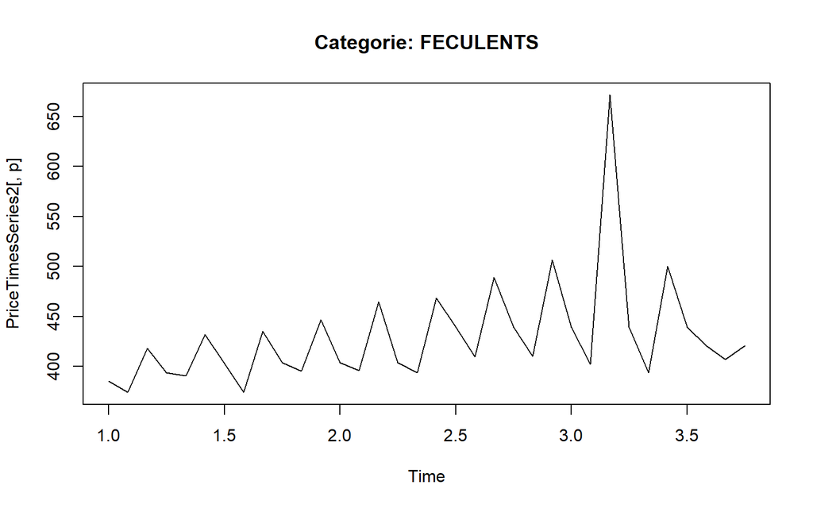

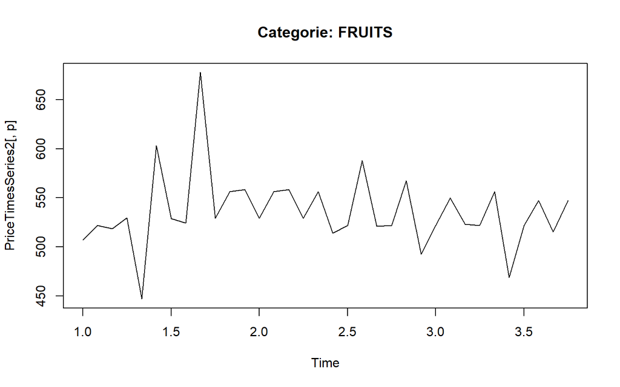

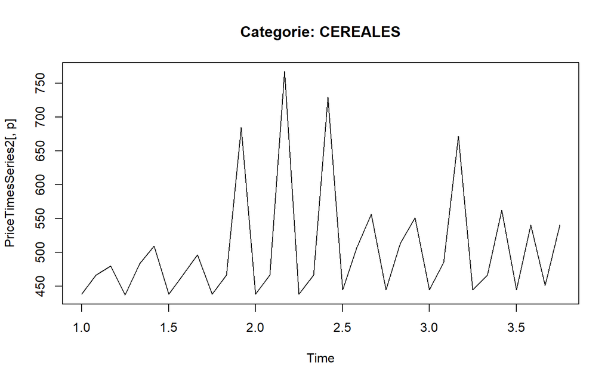

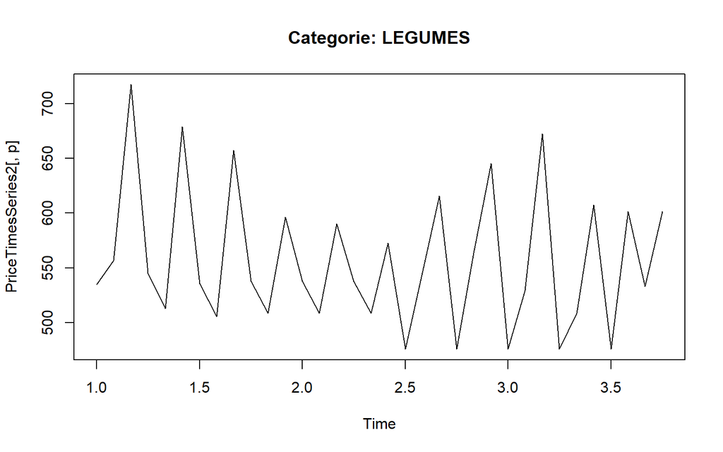

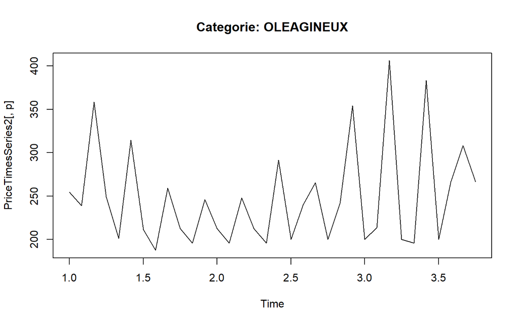

### Seasonal plots

```
## $`1`
```

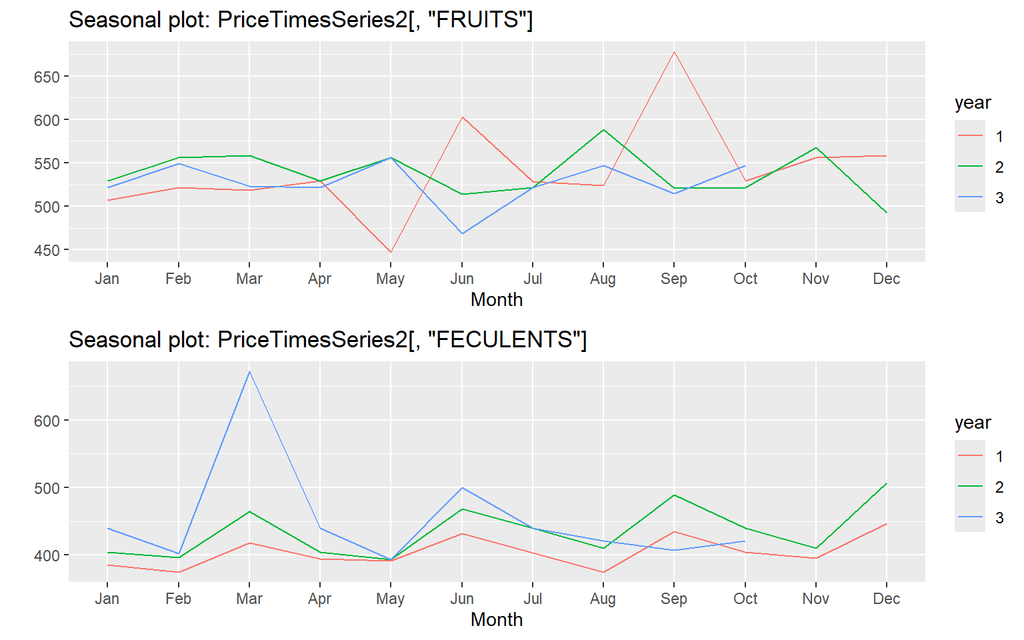

```
##
## $`2`
```

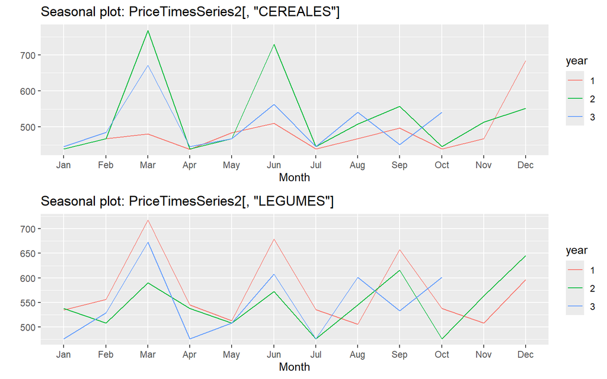

```
##
## $`3`
```

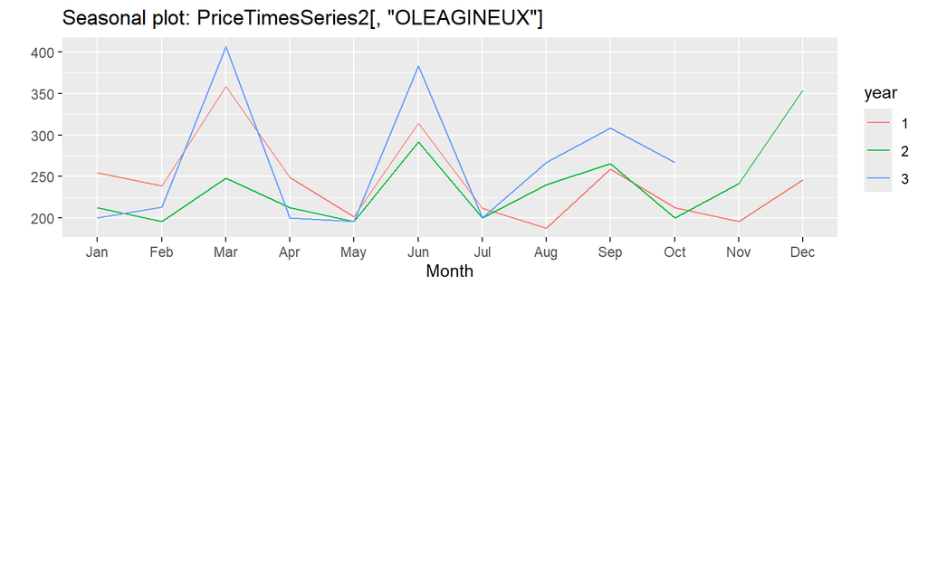

```
##
## attr(,"class")
## [1] "list"      "ggarrange"
```

### Autres Visualisations

SPECIFICITE

*Progression*<sup>1</sup>

CEREALES

[figure not shown]

FECULENTS

[figure not shown]

FRUITS

[figure not shown]

LEGUMES

[figure not shown]

OLEAGINEUX

[figure not shown]

```
## [1] "Categorie : FECULENTS"
```

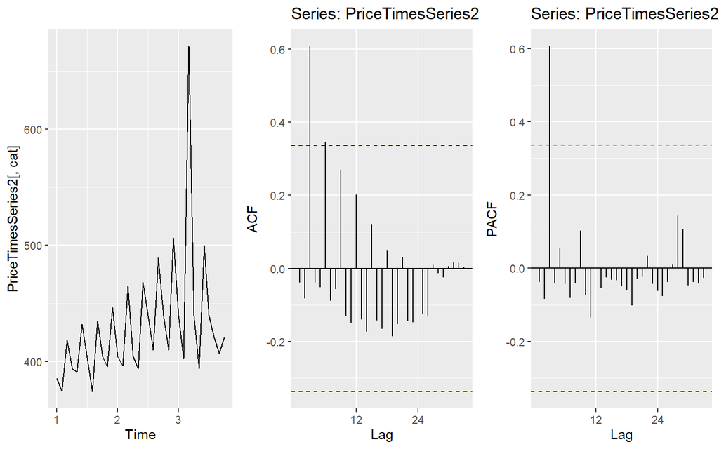

```
## [1] "Categorie : FRUITS"
```

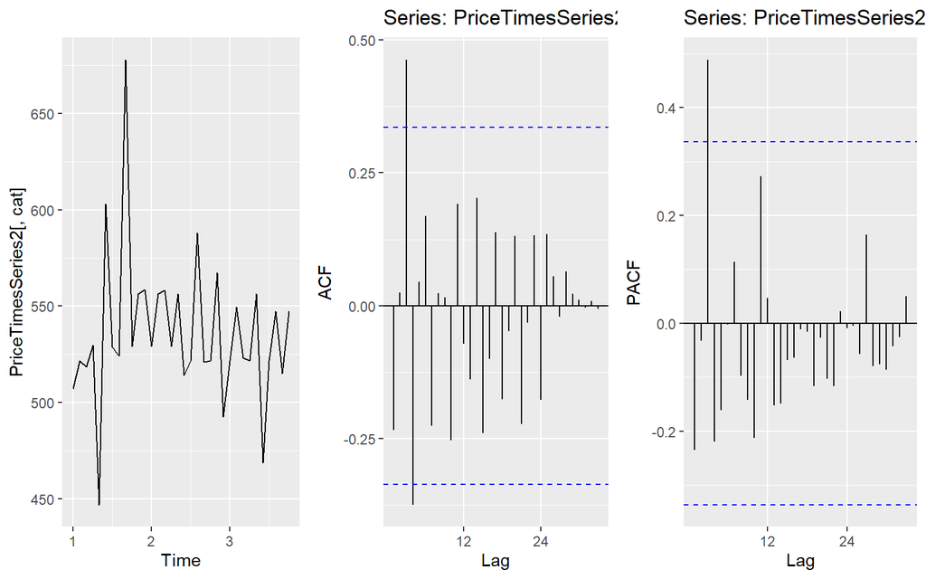

```
## [1] "Categorie : CEREALES"
```

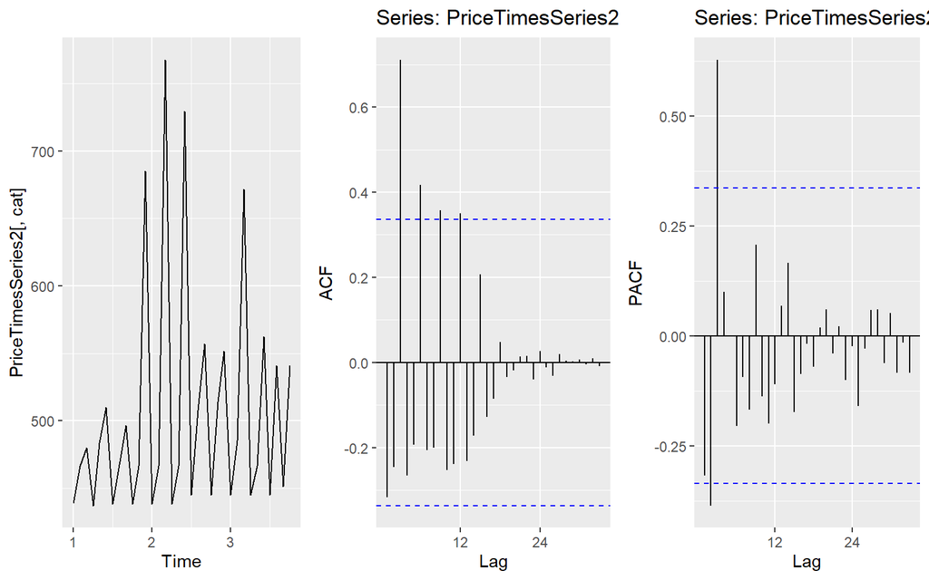

```
## [1] "Categorie : LEGUMES"
```

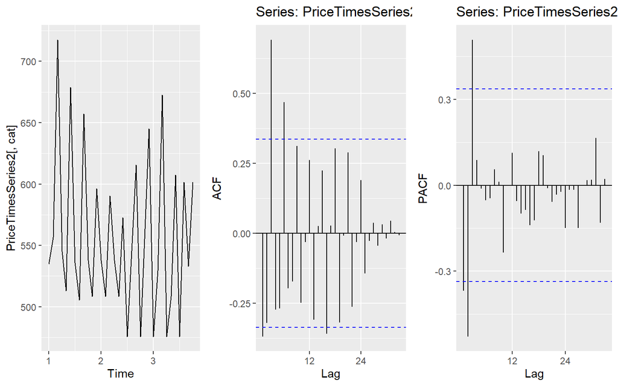

```
## [1] "Categorie : OLEAGINEUX"
```

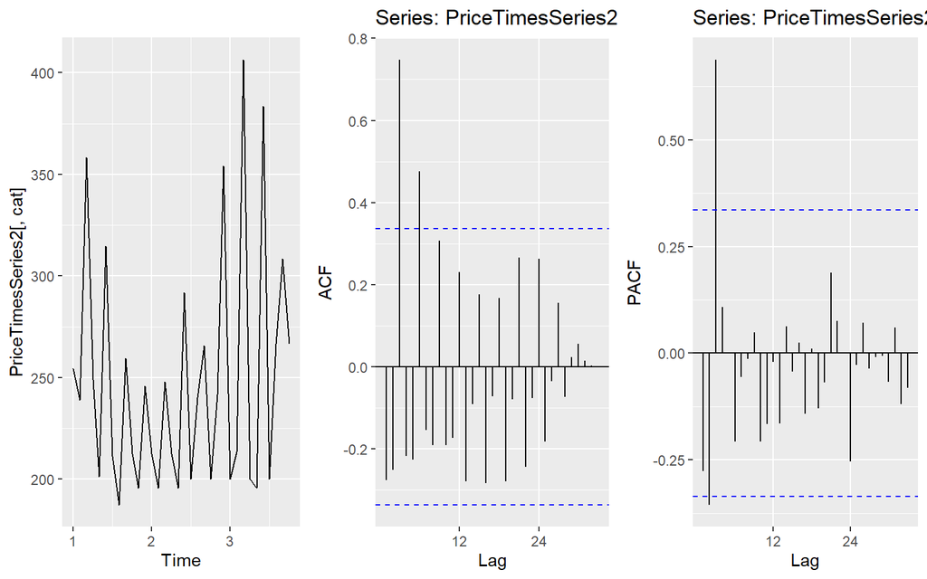

# Modélisation

## Test de stationnarité

**Résulats des tests de stationnarité**

| Test | Specificite | hypothese nulle | P-Value |
| --- | --- | --- | --- |
| ADF | FECULENTS | Non stationnaire | 0.99000000 |
| ADF | FRUITS | Non stationnaire | 0.74596728 |
| ADF | CEREALES | Non stationnaire | 0.43448294 |
| ADF | LEGUMES | Non stationnaire | 0.35047882 |
| ADF | OLEAGINEUX | Non stationnaire | 0.47147833 |
| PP | FECULENTS | Non stationnaire | 0.09267797 |
| PP | FRUITS | Non stationnaire | 0.07827257 |
| PP | CEREALES | Non stationnaire | 0.10943410 |
| PP | LEGUMES | Non stationnaire | 0.35340615 |
| PP | OLEAGINEUX | Non stationnaire | 0.29101307 |
| KPSS | FECULENTS | Stationnaire CP | 0.04114470 |
| KPSS | FRUITS | Stationnaire CP | 0.10000000 |
| KPSS | CEREALES | Stationnaire CP | 0.01108050 |
| KPSS | LEGUMES | Stationnaire CP | 0.01880843 |
| KPSS | OLEAGINEUX | Stationnaire CP | 0.02090886 |

## Etude de la spécificité FECULENTS

```
##   Test    P.Value Stationnaire
## 1  ADF 0.99000000          NON
## 2   PP 0.09267797          NON
## 3 KPSS 0.04114470          NON
```

## Stationnarité de la serie differencié une fois

```
##   Test   P.Value Stationnaire
## 1  ADF 0.7479833          NON
## 2   PP 0.0100000          OUI
## 3 KPSS 0.1000000          OUI
```

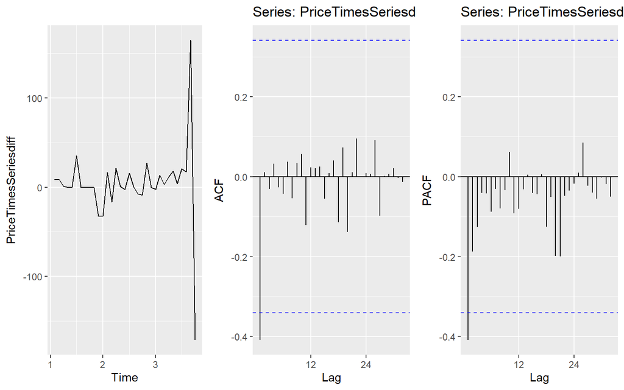

Des graphes ACF et PACF, nous estimons qmax et pmax: qmax=1 et pmax=1

**Modélisation ARIMA**

## ARIMA

```
## Series: PriceTimesSeriesF
## ARIMA(1,1,0)
##
## Coefficients:
##           ar1
##       -0.6765
## s.e.   0.1840
##
## sigma^2 = 1425:  log likelihood = -166.44
## AIC=336.89   AICc=337.29   BIC=339.88
##
## Training set error measures:
##                    ME     RMSE      MAE      MPE     MAPE      MASE        ACF1
## Training set 9.000326 36.62129 19.80876 1.581232 4.163009 0.3835355 -0.06497039
```

### Formule mathématique du modèle

[output not shown]

[output not shown]

Le modèle ARIMA(1,1,0) pour la série temporelle PriceTimesSeriesF montre que la valeur actuelle est principalement influencée par les valeurs des deux périodes précédentes. La composante autorégressive de premier ordre (AR(1)) avec la différenciation de premier ordre (I(1)) permet de capturer la dynamique de la série temporelle, tandis que le terme d’erreur capture les variations aléatoires. En résumé, la formule indique que pour prédire la valeur Yt à un instant t, nous utilisons une combinaison linéaire des valeurs des deux périodes précédentes avec des coefficients spécifiques, plus un terme d’erreur.

### Etude des residues

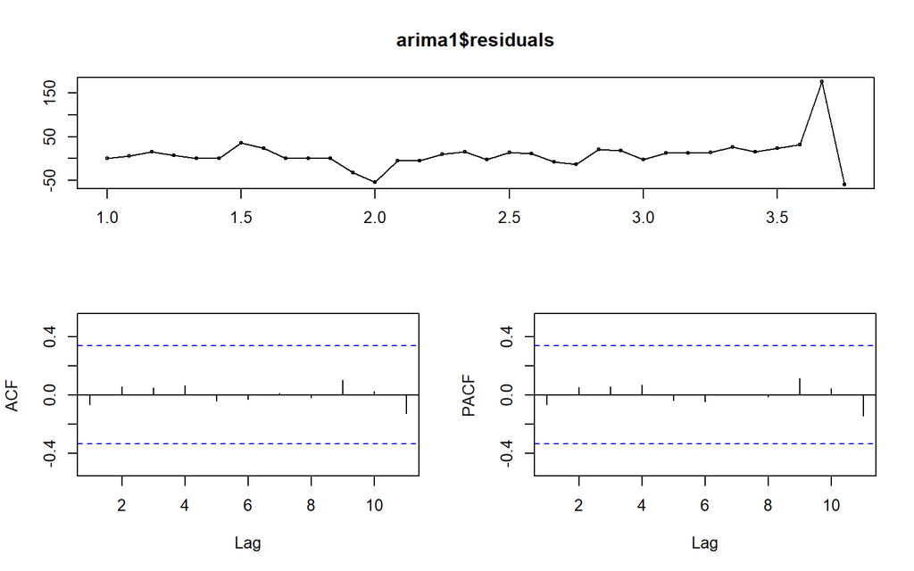

Les residus sont independants.

## Prediction

[figure not shown]

## Quelques insights et recommandation

La non stationnarité des prix des denrées alimentaires sur la période observée, met en évidence la sensibilité des prix des **produits locaux** aux politiques isolationniste. En effet, à partir de juillet 2020 le “grand Abidjan” (réunion de la ville d’Abidjan, ainsi que quelques villes adjacentes du sud de la CI) alors épicentre de la propagation de la COVID 19, se voit isolé par les mesures politiques destinés à contenir la propagation virale. Certaine ville clés de l’économie de la Côte d’Ivoire se retrouve en autarcie. S’en suit des pics sans précédents de la demande.

**Recommandations :**

- **Maintenir la fluidité des échanges commerciaux entre les villes** de la Côte d’Ivoire à travers :
  - *L’expansion et l’entretien du réseau routier*, Le manque de routes praticables, de ponts ou de moyens de transport adéquats peut augmenter les coûts de transport des denrées alimentaires, rendant les prix plus élevés dans certaines régions enclavées.
  - *La lutte contre l’insécurité sur nos routes*, Les conflits ou l’instabilité politique peuvent perturber les chaînes d’approvisionnement et limiter l’accès aux marchés, entraînant des prix plus élevés dans les zones affectées.
  - *L’encouragement des communications sur les prix des denrées alimentaires* au près des population, les consommateurs dans certaines régions peuvent avoir un accès limité aux informations sur les prix du marché, ce qui les rend plus vulnérables aux fluctuations et aux prix élevés.

# Conclusion

Cette analyse approfondie de la structure des prix des produits dans les différents marchés en Côte d’Ivoire révèle des dynamiques complexes influencées par divers facteurs économiques, politiques et sociaux. Les résultats montrent que les prix des denrées alimentaires ont subi des fluctuations significatives entre 2020 et 2022, principalement dues aux perturbations causées par la pandémie de COVID-19 et à d’autres instabilités.